# Chronic Absenteeism Report: 2025–26 (Preliminary)

NC State Board of Education Region 2 (Southeast)

Author

Affiliation

Dr. Shaun Kellogg

AttendNC Counts, Office of Research and Promising Practices, NCDPI

Published

September 8, 2026

# Introduction

**WarningPreliminary Data — 2025–26**

The district chronic absenteeism rates in this report are based on **preliminary 2025–26 data** and may change before final publication. Subgroup data for economically disadvantaged students, students with disabilities, and English learners are not yet available in the 2025–26 preliminary release, so the point-in-time subgroup equity and district deep-dive charts are limited to All Students and racial/ethnic groups. The subgroup trend chart is the exception: it draws on finalized historical data and shows all eight subgroups through 2024–25, with All Students, racial/ethnic groups, and Multiracial students extending into the 2025–26 preliminary release. The bright spot school analysis uses **2024–25 final results**, which will be updated when the full 2025–26 dataset is released.

Chronic absenteeism, defined as missing 10% or more of enrolled school days, has emerged as one of the most significant post-pandemic challenges in K–12 education. This report examines the 2025–26 chronic absenteeism (CA) landscape across the 12 traditional public school districts of NC State Board of Education Region 2 (Southeast), comparing district performance to state averages and to what would be expected given each district’s economic context.

The region’s enrollment-weighted average CA rate in 2025–26 is **26.0%**, compared to a statewide traditional-LEA average of 25.3%. District rates range from 18.3% to 34.5%. A key thread throughout this report is the distinction between districts that are above or below the poverty-adjusted expectation. Controlling for economic disadvantage in this way helps to reveal meaningful variation in performance that raw rates alone can potentially obscure.

**TipHow to read this report**

- **CA rate** is the share of students chronically absent (missing ≥10% of school days).
- **Poverty-adjusted performance** asks: given how many students in a district are experiencing economic hardship, how does the district’s CA rate compare to what we’d expect? To answer this, we fit a trend line through all 115 matched traditional public school districts in North Carolina using the share of economically disadvantaged students to predict each district’s CA rate. A district’s **residual** is the gap between its actual rate and that prediction — a **negative number means the district is doing better than expected** for its poverty level; a positive number means it is doing worse.
- Colors throughout: **Blue = better than expected for poverty level · Orange = worse than expected**.

# Regional Snapshot

## CA Rates by District

Districts are ranked by 2025–26 CA rate. Color reflects poverty-adjusted performance: blue bars are performing better than their poverty level would predict, orange bars are performing worse.

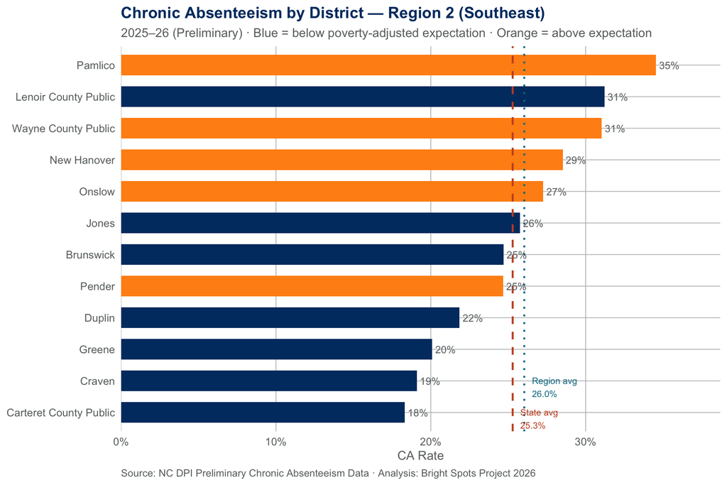

## District Summary

The table below summarizes key metrics for each district: CA rate, historical peak, improvement since peak, performance relative to the state average, and the poverty-adjusted residual. Note that peak rates and improvement are computed across all available years, including 2025–26 preliminary data.

**Region 2 (Southeast) — Chronic Absenteeism Summary by District**

2025–26 School Year (Preliminary) · Traditional LEAs only · State average: **25.3%**

| District | **Context** County | **Context** Schools | **Context** % EDS | **Absenteeism rates** CA Rate | **Absenteeism rates** Peak Rate | **Absenteeism rates** Improvement<sup>1</sup> | **Benchmarks** vs. State | **Benchmarks** Poverty-Adj. Residual<sup>2</sup> |
| --- | --- | --- | --- | --- | --- | --- | --- | --- |
| Pamlico | Pamlico | 4 | 54.4% | 34.5% | 51.9% | +17.3 | +9.3 | +6.3 |
| Lenoir County Public | Lenoir | 17 | 70.8% | 31.2% | 40.3% | +9.1 | +5.9 | −3.5 |
| Wayne County Public | Wayne | 31 | 59.4% | 31.0% | 44.0% | +13.0 | +5.8 | +0.8 |
| New Hanover | New Hanover | 39 | 42.6% | 28.5% | 28.5% | +0.0 | +3.2 | +4.9 |
| Onslow | Onslow | 37 | 48.7% | 27.3% | 32.8% | +5.5 | +2.0 | +1.2 |
| Jones | Jones | 5 | 67.7% | 25.8% | 45.8% | +20.0 | +0.5 | −7.8 |
| Brunswick | Brunswick | 20 | 50.7% | 24.7% | 32.1% | +7.4 | −0.6 | −2.1 |
| Pender | Pender | 18 | 40.4% | 24.7% | 35.9% | +11.2 | −0.6 | +1.9 |
| Duplin | Duplin | 13 | 65.3% | 21.9% | 25.0% | +3.2 | −3.4 | −10.7 |
| Greene | Greene | 6 | 68.8% | 20.1% | 27.9% | +7.8 | −5.2 | −13.9 |
| Craven | Craven | 25 | 53.8% | 19.1% | 36.7% | +17.6 | −6.2 | −8.9 |
| Carteret County Public | Carteret | 15 | 39.0% | 18.3% | 38.6% | +20.3 | −7.0 | −3.9 |

<sup>1</sup> Improvement = peak CA rate minus 2025–26 rate (positive = improved); peak computed across all years including preliminary 2025–26.  
<sup>2</sup> Poverty-adjusted residual from weighted OLS: district CA rate ~ % EDS, fit across matched traditional LEAs statewide using 2025–26 preliminary data. Negative = better than expected for poverty level.  
Source: NC DPI Preliminary Chronic Absenteeism Data · Analysis: Bright Spots Project 2026

# Trends Over Time

## District Trajectories, 2018–2026

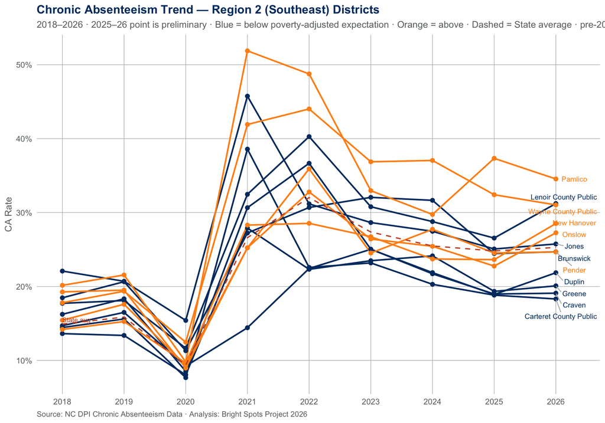

## Subgroup Trends, 2018–2026

The chart below shows enrollment-weighted average CA rates for Region 2 by student subgroup (solid lines) compared to statewide averages for the same subgroups (dashed lines), covering every subgroup available in the historical data. All Students, Black, White, Hispanic, and Multiracial lines extend through the 2025–26 preliminary release; Econ. Disadvantaged, Students w/ Disabilities, and English Learners are not yet available for 2025–26 and their lines end at 2024–25.

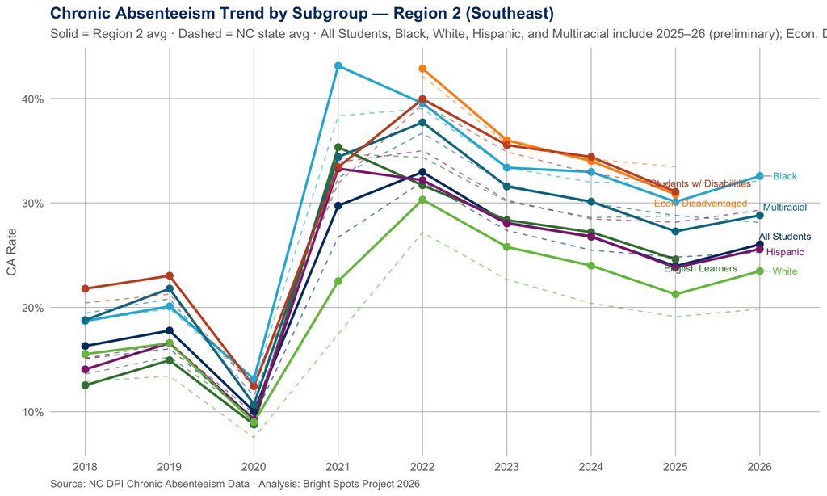

# Geographic and Poverty Context

## Regional Map

The maps below show the same Region 2 counties from two perspectives. The left panel shows the preliminary 2025–26 CA rate; the right panel shows the poverty-adjusted residual (i.e., how each district performs relative to what would be expected given its share of economically disadvantaged students). Counties with multiple districts reflect the enrollment-weighted average across those districts.

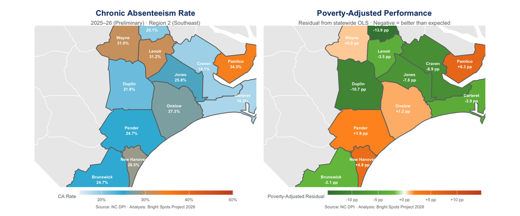

## Poverty-Adjusted Performance

The chart below shows all 115 matched traditional public school districts in North Carolina (gray dots), each plotted by its preliminary 2025–26 chronic absenteeism rate and the share of its students experiencing economic disadvantage. The diagonal line represents the CA rate a district would be *expected* to have given its poverty level. Districts below the line are doing better than expected for their economic context; districts above it are doing worse. Region 2 districts are highlighted in blue (better than expected) or orange (worse than expected).

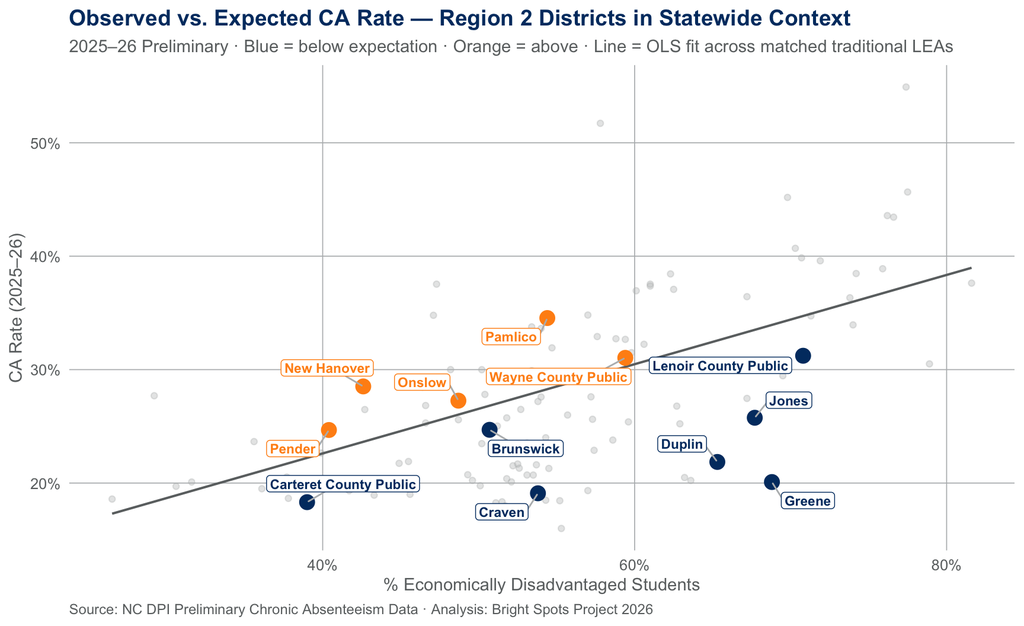

# Subgroup Equity

The chart below compares preliminary 2025–26 CA rates by student subgroup across Region 2 districts. Gray dots are individual district rates; the blue circle is the enrollment-weighted Region 2 average; the orange diamond is the statewide average. Because EDS and SWD subgroup data are not yet available in the preliminary release, this chart shows All Students, Black, White, and Hispanic students only.

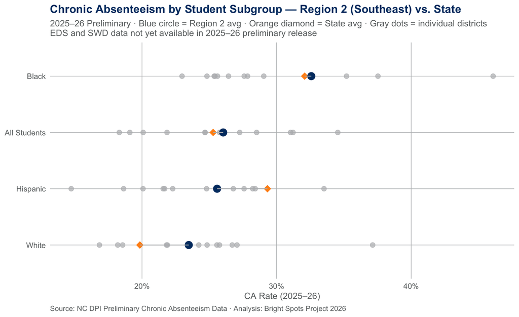

# District Deep Dives

The two sections below examine one exemplary district and one area of significant concern, selected based on their preliminary 2025–26 poverty-adjusted residuals. The exemplary district — **Greene** — carries the largest negative residual in the region (-13.9 pp), performing substantially better than comparable-poverty peers statewide. The district of concern — **Pamlico** — carries the largest positive residual (+6.3 pp), performing worse than its poverty level would predict. Each district is examined through its historical trajectory and a 2025–26 subgroup breakdown (All Students and racial/ethnic groups).

## Greene

Greene serves 2,728 students across 6 schools. With 68.8% of students economically disadvantaged, its preliminary 2025–26 CA rate of 20.1% and poverty-adjusted residual of -13.9 pp make it the district performing furthest below the statewide poverty-adjusted expectation in the region.

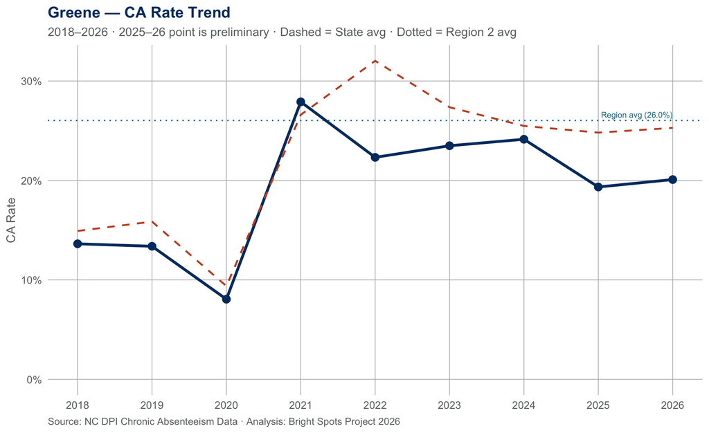

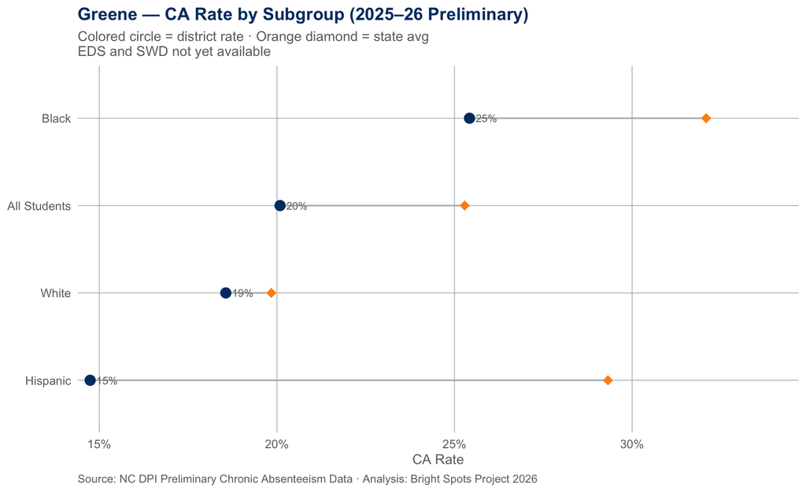

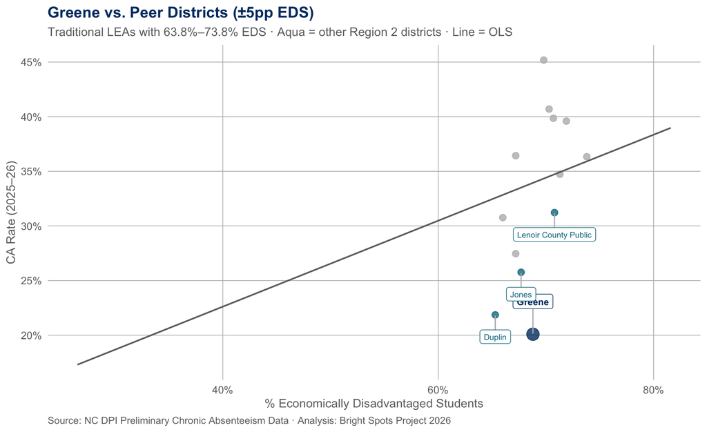

## Pamlico

Pamlico serves 1,126 students across 4 schools. At 54.4% EDS, its preliminary 2025–26 CA rate of 34.5% and poverty-adjusted residual of +6.3 pp indicate that the district’s CA challenge extends beyond what its poverty level alone would predict.

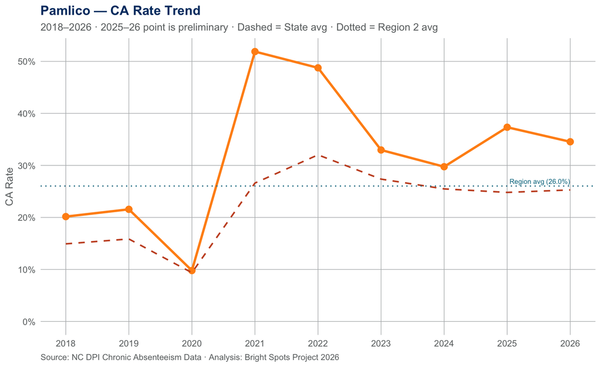

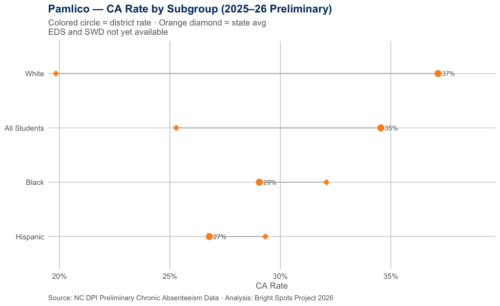

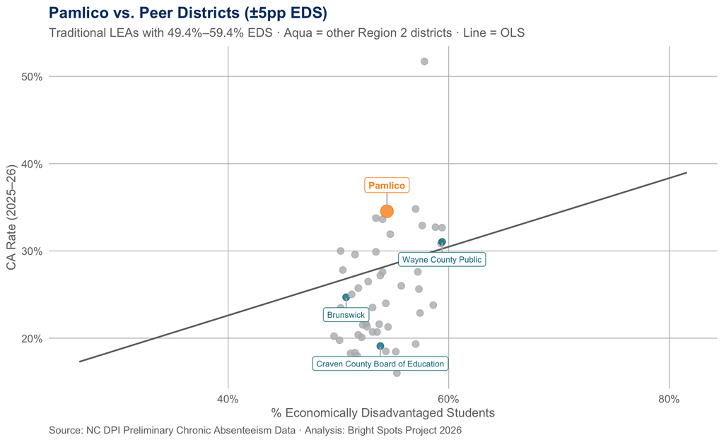

# Bright Spot Schools

**Note2024–25 Bright Spot Identifications**

The map below uses **2024–25 final bright spot identifications**. The value-added model that identifies bright spot schools requires complete, finalized data and will be rerun when the full 2025–26 dataset is released. Schools that appear here may or may not qualify under the 2025–26 analysis; treat these as a starting point for learning conversations rather than a definitive current list.

The map below shows 2024–25 Bright Spot candidates statewide, zoomed to Region 2 (Southeast). Markers are colored by grade band; click any school for details including enrollment, CA rates, and model residual. Use the layer controls to filter by candidate tier (Exceptional, Strong, Promising).

[interactive chart not shown]

## Learning From Bright Spots

This map is designed as a **learning tool, not a scorecard**. Each marker represents a school that — as of 2024–25 — was both outperforming expectations for its context and had made meaningful progress reducing chronic absenteeism since the post-pandemic peak.

**Click any school marker** to see key metrics including:

- **Peak rate (2021–22)** and **current rate (2024–25)** — how much the school’s CA rate changed since the pandemic peak
- **Model-expected rate** — the rate predicted for a school with similar characteristics (poverty level, size, grade configuration, and district)
- **Improvement (pp)** — the percentage-point reduction since the 2021–22 peak
- **vs. Expected** — how far below the predicted rate the school’s current rate falls

### Explore Further with the Dashboard

The [AttendNC Bright Spots Dashboard](https://sbkellogg.shinyapps.io/bright-spots-app-v2/) extends this map with filters that let you narrow to schools most comparable to your own — by county, grade band, enrollment, poverty level, and bright spot tier.

**NoteThree questions to guide your exploration**

- **Who is improving in a context like ours?** Use the county, grade band, enrollment, and student demographics filters to focus on schools facing circumstances similar to yours.
- **Which schools are the clearest bright spots?** The **Exceptional**, **Strong**, and **Promising** tiers indicate how far a school is outperforming model expectations — start with Exceptional schools for the strongest signal.
- **Where should we learn more?** Use the table to identify a small set of schools worth reaching out to, visiting, or inviting into a peer-learning conversation.

If your school is a bright spot and you’d like to share what worked, [submit a practice here](https://forms.cloud.microsoft/r/vAG6SC1Kye).

For full background on how bright spot schools are identified, visit the [AttendNC Bright Spots](https://www.dpi.nc.gov/districts-schools/office-research-promising-practices/attendnc-counts/attendnc-bright-spots) page on the NC DPI website.

# Methodology Notes

**Data source.** District-level chronic absenteeism data for 2025–26 are drawn from a preliminary release (`Prelim_ChronicAbsenteeism_2526.xlsx`) and may change before final publication. Historical data (2017–18 through 2024–25) are from NC DPI’s finalized chronic absenteeism files. Analyses are restricted to traditional public school LEAs with a record in the 2024–25 pipeline.

**District name changes.** Two districts appear under new names in 2025–26: Chowan County Schools is now **Edenton-Chowan Schools**, and Pasquotank County Schools is now **Elizabeth City-Pasquotank Public Schools**. Because the 2024–25 pipeline already uses these updated names, historical trend comparisons are seamless with no additional crosswalk required.

**Subgroup availability.** The preliminary 2025–26 data includes All Students, sex, grade, and racial/ethnic subgroups. EDS (economically disadvantaged students), SWD (students with disabilities), and ELS (English learners) subgroup breakdowns are not yet available and will be incorporated when the final dataset is released.

**District-level aggregation.** All district-level CA rates are computed by summing chronically absent students across schools within the district and dividing by total enrollment — a true enrollment-weighted rate rather than an average of school-level percentages.

**Poverty-adjusted residuals.** A weighted ordinary least squares model (`p_current ~ pct_eds`, weighted by district enrollment) was fit across 115 matched traditional LEAs using 2025–26 preliminary CA rates and 2025–26 EDS rates (from APR 2026). A negative residual indicates better-than-expected performance; a positive residual indicates worse than expected.

**Peak improvement.** The “Improvement” column reflects each district’s historical peak CA rate (the highest rate across all years, including preliminary 2025–26) minus the 2025–26 preliminary rate.

**Bright spot identification.** Bright spot schools are identified using a beta-binomial mixed-effects model fit to 2024–25 finalized data. Schools must meet three criteria: enrollment ≥ 100, quasi-standardized residual ≤ −1.25, and improvement ≥ 5 percentage points from the 2021–22 peak. This analysis will be rerun on final 2025–26 data when available.